# АНАЛИЗ РЕГРЕССИИ SLEEP75

```python
df
```

|  | age | black | case | clerical | construc | educ | earns74 | gdhlth | inlf | leis1 | ... | spwrk75 | totwrk | union | worknrm | workscnd | exper | yngkid | yrsmarr | hrwage | agesq |
| --- | --- | --- | --- | --- | --- | --- | --- | --- | --- | --- | --- | --- | --- | --- | --- | --- | --- | --- | --- | --- | --- |
| 0 | 32 | 0 | 1 | 0.000000 | 0.000000 | 12 | 0 | 0 | 1 | 3529 | ... | 0 | 3438 | 0 | 3438 | 0 | 14 | 0 | 13 | 7.070004 | 1024 |
| 1 | 31 | 0 | 2 | 0.000000 | 0.000000 | 14 | 9500 | 1 | 1 | 2140 | ... | 0 | 5020 | 0 | 5020 | 0 | 11 | 0 | 0 | 1.429999 | 961 |
| 2 | 44 | 0 | 3 | 0.000000 | 0.000000 | 17 | 42500 | 1 | 1 | 4595 | ... | 1 | 2815 | 0 | 2815 | 0 | 21 | 0 | 0 | 20.529997 | 1936 |
| 3 | 30 | 0 | 4 | 0.000000 | 0.000000 | 12 | 42500 | 1 | 1 | 3211 | ... | 1 | 3786 | 0 | 3786 | 0 | 12 | 0 | 12 | 9.619998 | 900 |
| 4 | 64 | 0 | 5 | 0.000000 | 0.000000 | 14 | 2500 | 1 | 1 | 4052 | ... | 1 | 2580 | 0 | 2580 | 0 | 44 | 0 | 33 | 2.750000 | 4096 |
| ... | ... | ... | ... | ... | ... | ... | ... | ... | ... | ... | ... | ... | ... | ... | ... | ... | ... | ... | ... | ... | ... |
| 701 | 45 | 0 | 702 | 0.182331 | 0.030075 | 12 | 5500 | 1 | 0 | 5069 | ... | 1 | 2026 | 0 | 2026 | 0 | 27 | 0 | 18 | NaN | 2025 |
| 702 | 34 | 0 | 703 | 0.182331 | 0.030075 | 10 | 2500 | 0 | 0 | 5885 | ... | 0 | 675 | 1 | 465 | 210 | 18 | 0 | 4 | NaN | 1156 |
| 703 | 37 | 0 | 704 | 0.182331 | 0.030075 | 12 | 3500 | 1 | 0 | 4719 | ... | 1 | 1851 | 0 | 1851 | 0 | 19 | 0 | 17 | NaN | 1369 |
| 704 | 54 | 0 | 705 | 0.182331 | 0.030075 | 17 | 32500 | 1 | 0 | 5149 | ... | 1 | 1961 | 1 | 1481 | 480 | 31 | 0 | 22 | NaN | 2916 |
| 705 | 30 | 0 | 706 | 0.182331 | 0.030075 | 16 | 6750 | 1 | 0 | 4747 | ... | 0 | 2363 | 0 | 2363 | 0 | 8 | 1 | 9 | NaN | 900 |

706 rows × 34 columns

# Анализ регрессии sleep ~ age + educ + male + marr + totwrk + yngkid

```python
model = smf.ols('sleep ~ age + educ + male + marr + totwrk + yngkid',data = df).fit()
model.summary()
```

OLS Regression Results

| Dep. Variable: | sleep | R-squared: | 0.122 |
| --- | --- | --- | --- |
| Model: | OLS | Adj. R-squared: | 0.115 |
| Method: | Least Squares | F-statistic: | 16.23 |
| Date: | Thu, 29 Dec 2022 | Prob (F-statistic): | 1.54e-17 |
| Time: | 09:42:24 | Log-Likelihood: | -5259.5 |
| No. Observations: | 706 | AIC: | 1.053e+04 |
| Df Residuals: | 699 | BIC: | 1.057e+04 |
| Df Model: | 6 |  |  |
| Covariance Type: | nonrobust |  |  |

|  | coef | std err | t | P>\|t\| | [0.025 | 0.975] |
| --- | --- | --- | --- | --- | --- | --- |
| Intercept | 3615.3507 | 119.506 | 30.252 | 0.000 | 3380.717 | 3849.984 |
| age | 1.9704 | 1.522 | 1.294 | 0.196 | -1.019 | 4.959 |
| educ | -11.5979 | 5.878 | -1.973 | 0.049 | -23.139 | -0.057 |
| male | 83.1221 | 35.220 | 2.360 | 0.019 | 13.973 | 152.272 |
| marr | 30.3392 | 42.251 | 0.718 | 0.473 | -52.615 | 113.293 |
| totwrk | -0.1645 | 0.018 | -9.098 | 0.000 | -0.200 | -0.129 |
| yngkid | 0.1919 | 50.444 | 0.004 | 0.997 | -98.849 | 99.232 |

| Omnibus: | 64.461 | Durbin-Watson: | 1.947 |
| --- | --- | --- | --- |
| Prob(Omnibus): | 0.000 | Jarque-Bera (JB): | 171.240 |
| Skew: | -0.468 | Prob(JB): | 6.54e-38 |
| Kurtosis: | 5.224 | Cond. No. | 1.78e+04 |

Notes:  
[1] Standard Errors assume that the covariance matrix of the errors is correctly specified.  
[2] The condition number is large, 1.78e+04. This might indicate that there are  
strong multicollinearity or other numerical problems.

# Оценивание значимости регрессоров

Критическое значение по Стьюденту **tcr= СТЬЮДЕНТ.ОБР.2Х(0,05;706-7)= 1,96 (при уровне значимости 5%)**. Если взять все значения \tstat\ (в модуле), то значимыми являются **intercept, educ, male, totwrk**. (Результат по p-value точно такой же)

# Оценим регрессию на наличие мультиколлинеарности

#### Построим матрицу корреляций

```python
data = pd.read_csv('https://www.picostat.com/system/files/datasets/dataset-48240.csv')
numeric_col = ['age', 'educ', 'male', 'marr', 'totwrk', 'yngkid']
corr = data.loc[:,numeric_col].corr()
print(corr)
```

```
             age      educ      male      marr    totwrk    yngkid
age     1.000000 -0.265831  0.031939  0.017558 -0.049570 -0.319698
educ   -0.265831  1.000000  0.035764 -0.032785  0.032604  0.104782
male    0.031939  0.035764  1.000000  0.167121  0.376458  0.106131
marr    0.017558 -0.032785  0.167121  1.000000 -0.025122  0.135132
totwrk -0.049570  0.032604  0.376458 -0.025122  1.000000  0.008819
yngkid -0.319698  0.104782  0.106131  0.135132  0.008819  1.000000
```

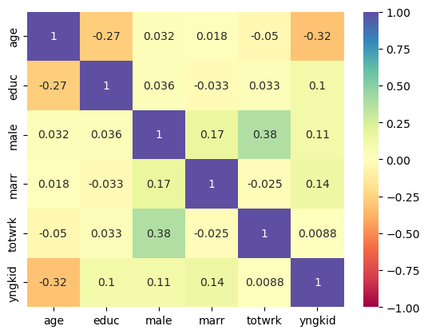

```python
pearson = data.loc[:,numeric_col].corr()
sns.heatmap(data=pearson,
            annot=True, vmin=-1, vmax=1, center= 0, cmap='Spectral');
```

Визуально очень сложно оценить, как изменение одной величины влияет на изменение других из таблицы. Но если мы построим **корреляционную матрицу Пирсона** и изобразим ее в виде **тепловой карты**, то все станет гораздо нагляднее. Коэффициент корреляции колеблется от -1 до +1. 0 корреляция означает, что две переменные не зависят друг от друга. Положительная корреляция указывает на то, что переменные движутся в одном направлении, а отрицательная корреляция указывает на противоположное. Как можно заметить, значение 1 только на диагонали (что нормально, так как коэффициент коррелирует сам с собой), в остальном корреляция небольшая => **мультиколинеарности нет**.

# Посмотрим на зависимость регрессоров от статуса человека (женат/замужем или нет)

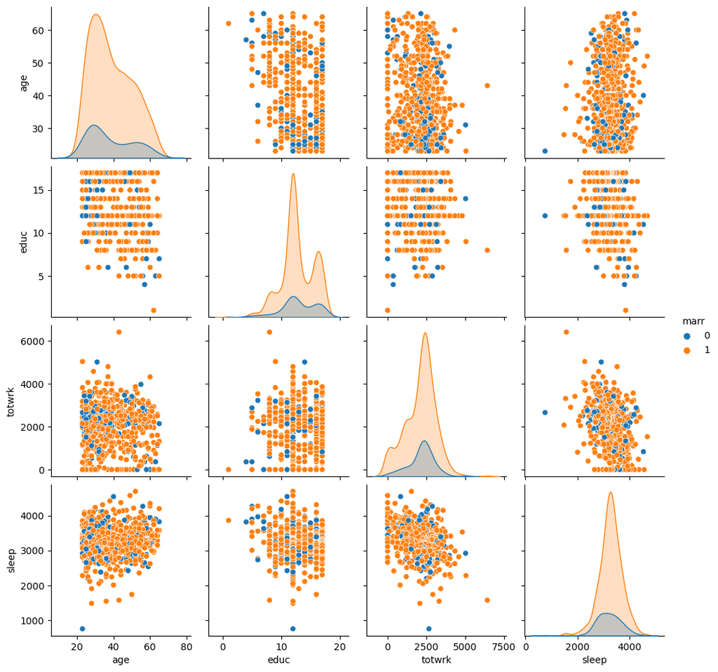

```python
sns.pairplot(df[['age','educ','totwrk','sleep', 'marr']], hue='marr')
```

# Анализ влияния отдельных регрессоров на количество сна

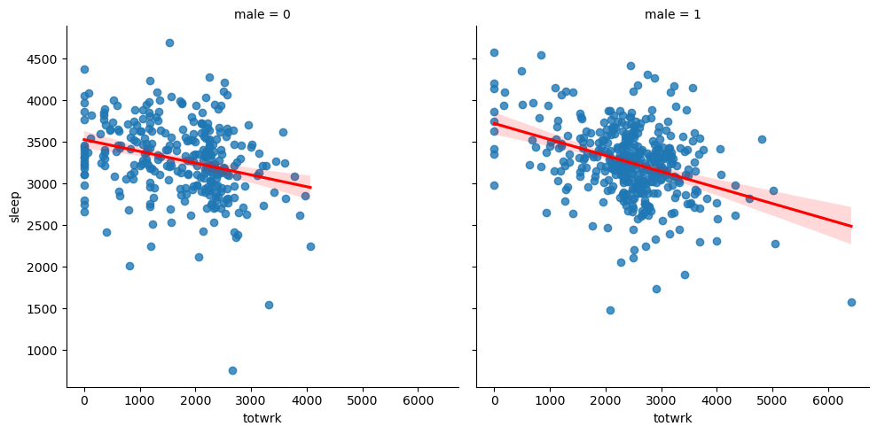

```python
df = pd.read_csv('https://www.picostat.com/system/files/datasets/dataset-48240.csv')
sns.lmplot(data=df, x='totwrk',
           y='sleep',
           col='male',line_kws={'color':'red'} );
```

На этих двух графиках мы можем увидеть зависимость количества сна в неделю от рабочих часов в двух подмножествах (в разрезе деления на мужчин и женщин). На первом графике изображена ситуация для женщин, на втором - для мужчин. В целом, ситуация одинаковая и для мужчин, и для женщин

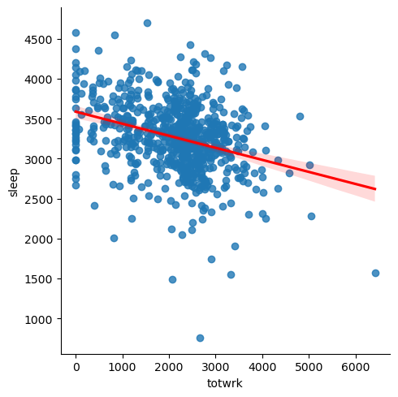

```python
df = pd.read_csv('https://www.picostat.com/system/files/datasets/dataset-48240.csv')
sns.lmplot(data=df, x = 'totwrk', y = 'sleep',line_kws={'color':'red'} )
```

На этом графике можно увидеть ситуацию в целом. Заметно, что при увеличении количества рабочих часов, количество сна уменьшается (что очень печально(((((()

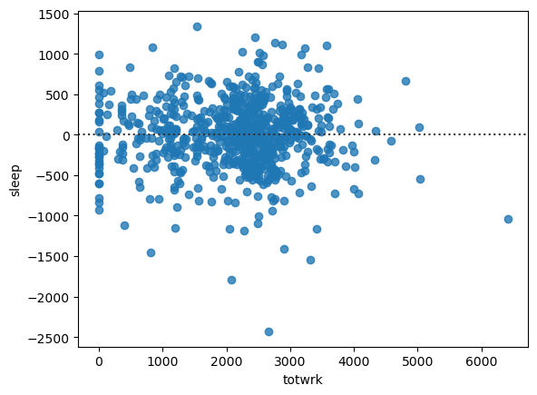

```python
df = pd.read_csv('https://www.picostat.com/system/files/datasets/dataset-48240.csv')
sns.residplot(data=df, x = 'totwrk', y = 'sleep')
```

График позволяет визуально оценить приемлемость простой линейной регрессии. Изображены линия регрессии в горизонтальном виде, а остатки в виде точек и если эти точки равномерно сгруппированы по обе стороны прямой, то линейную модель можно считать приемлемой. Если в остатках видна структура, то линейная модель не является приемлемой. В данном случае тяжело сделать вывод о приемлемости регрессии, потому что определенная структура присутствует. Остататки в основном в центре, распределены неравномерно в правой части, приемлемость этой регрессии под вопросом, нужен дальнейший анализ.

```
eval_env: 1
```

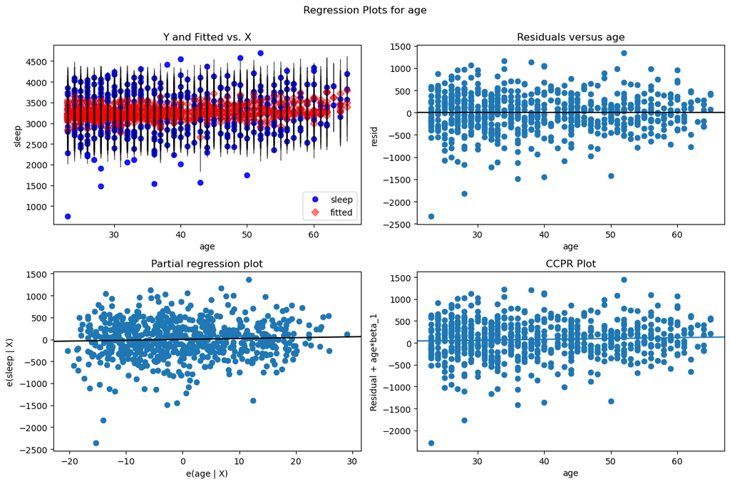

```python
model = smf.ols('sleep ~ age + educ + male + marr + totwrk + yngkid',data = df).fit()
fig = plt.figure(figsize=(12,8))
fig = sm.graphics.plot_regress_exog(model, 'age', fig=fig)
```

```
eval_env: 1
```

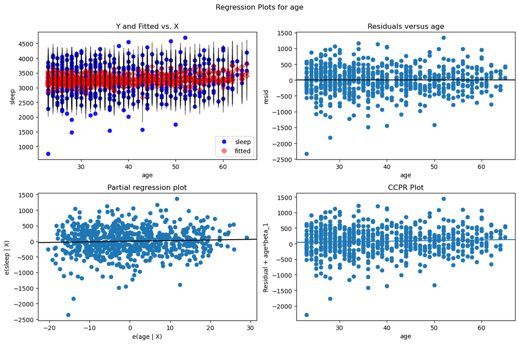

```python
model_linear = smf.ols('sleep ~ age + educ + male + marr + totwrk + yngkid', data = df).fit()
fig = plt.figure(figsize=(12,8))
fig = sm.graphics.plot_regress_exog(model_linear, 'age', fig=fig)
```

```
eval_env: 1
```

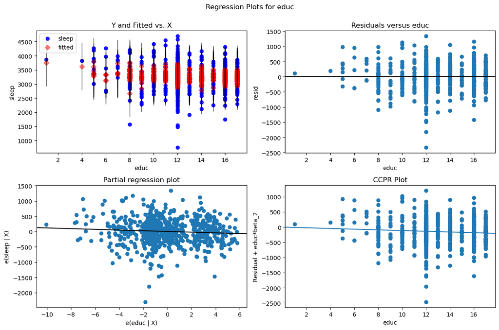

```python
fig = plt.figure(figsize=(12,8))
fig = sm.graphics.plot_regress_exog(model_linear, 'educ', fig=fig)
```

```
eval_env: 1
```

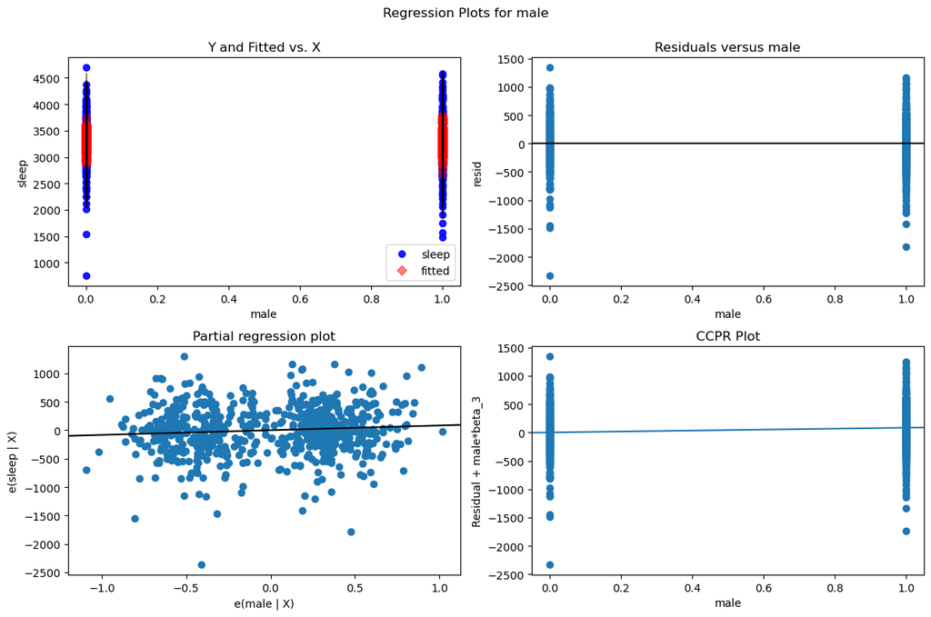

```python
fig = plt.figure(figsize=(12,8))
fig = sm.graphics.plot_regress_exog(model_linear, 'male', fig=fig)
```

```
eval_env: 1
```

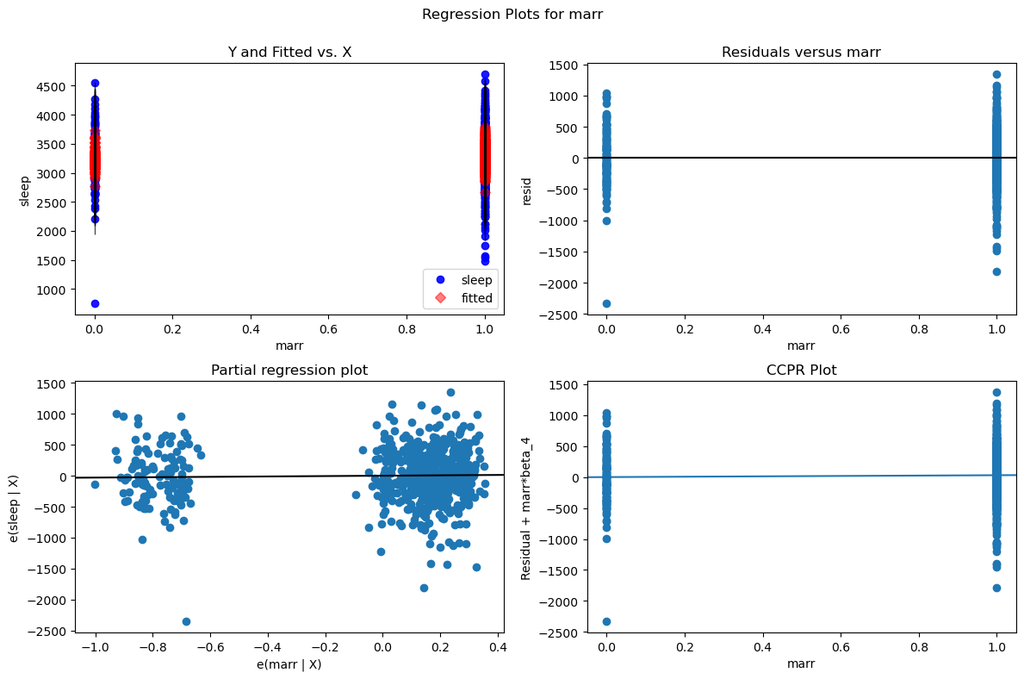

```python
fig = plt.figure(figsize=(12,8))
fig = sm.graphics.plot_regress_exog(model_linear, 'marr', fig=fig)
```

```
eval_env: 1
```

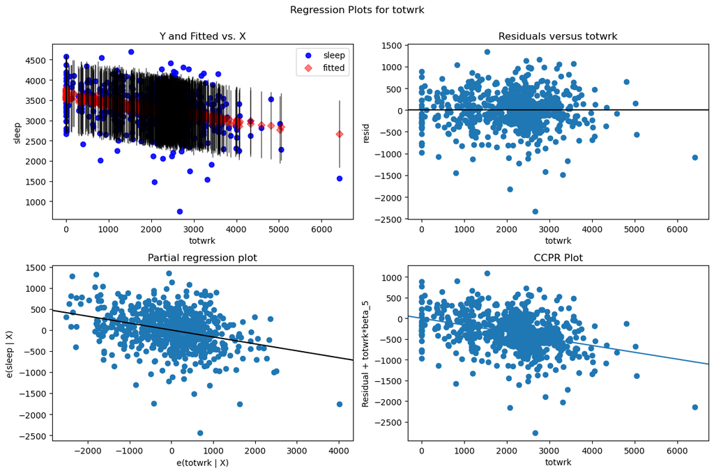

```python
fig = plt.figure(figsize=(12,8))
fig = sm.graphics.plot_regress_exog(model_linear, 'totwrk', fig=fig)
```

```
eval_env: 1
```

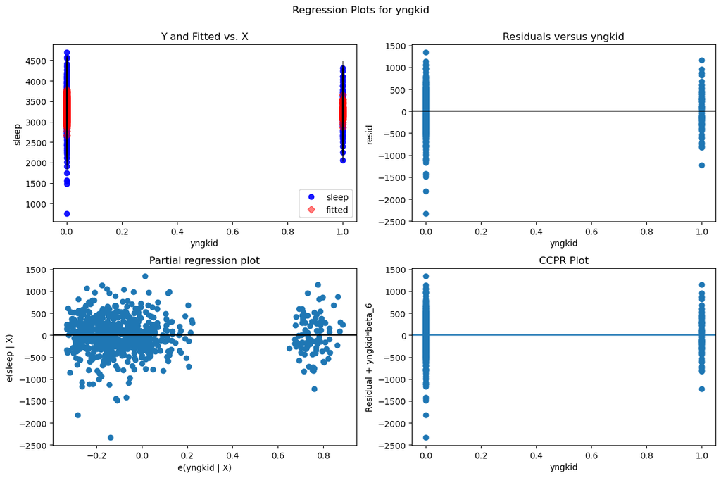

```python
fig = plt.figure(figsize=(12,8))
fig = sm.graphics.plot_regress_exog(model_linear, 'yngkid', fig=fig)
```

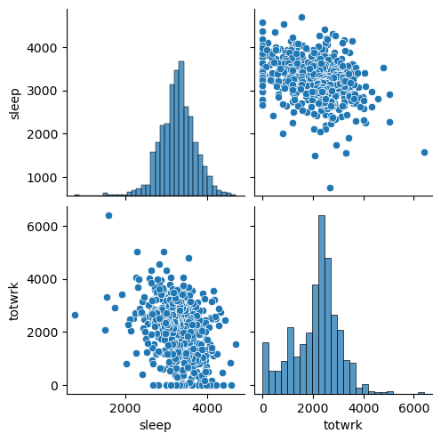

```python
sns.pairplot(df[['sleep','totwrk']])
```

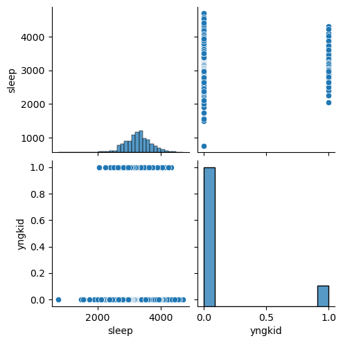

```python
sns.pairplot(df[['sleep','yngkid']])
```

# Анализ на гетероскедастичность

```python
from statsmodels.compat import lzip
import statsmodels.stats.api as sms
names = ['Lagrange multiplier statistic', 'p-value','f-value', 'f p-value']
test = sms.het_breuschpagan(model.resid, model.model.exog)
lzip(names, test)
```

```
[('Lagrange multiplier statistic', 11.64352665912553),
 ('p-value', 0.07041044774628981),
 ('f-value', 1.9535655068663882),
 ('f p-value', 0.07006343103135232)]
```

### Тест Бройша-Пагана

Тест использует следующие нулевые и альтернативные гипотезы:

- **H0**: присутствует гомоскедастичность
- **H1**: гомоскедастичность отсутствует (т.е. гетероскедастичность существует)

Статистика множителя Лагранжа = 11,64 , а значение p-value равно 0,0704. Так как это p-значение (0,07) > 0,05, мы **не отвергаем H0**: нет доказательств того, что в регрессии присутствует гетероскедастичность

```python
from sklearn. linear_model import LinearRegression
from statsmodels. stats.diagnostic import het_white
import statsmodels.api as sm
import pandas as pd
data = pd.read_csv('https://www.picostat.com/system/files/datasets/dataset-48240.csv')
y = data['sleep']
x = data[['age', 'educ','male','marr','totwrk','yngkid']]
x = sm.add_constant (x)
model = sm. OLS (y, x). fit ()
white_test = het_white(model. resid , model. model.exog)
labels = ['Test Statistic', 'Test Statistic p-value', 'F-Statistic', 'F-Test p-value']
print(dict(zip(labels, white_test)))
```

```
{'Test Statistic': 27.425517007729546, 'Test Statistic p-value': 0.2850127477988968, 'F-Statistic': 1.1468144833014464, 'F-Test p-value': 0.2854872232597941}
```

# Тест Уайта

- Тестовая статистика = 27,43
- Соответствующее значение p-value = 0,29

*Гипотезы в тесте Уайта*:

- H0: присутствует гомоскедастичность (остатки равномерно разбросаны)
- H1: присутствует гетероскедастичность (остатки разбросаны неравномерно)

Поскольку p-значение не меньше 0,05, мы не можем отвергнуть нулевую гипотезу => гетероскедастичность отсутствует